# Preprocessing Imagery

## **Overview:**

1. Load scene manifest
2. Cloud masking with S2 SCL (for L2A only) + Clip to AOI
3. 2D verification plot
4. Save processed scenes and the catalog of masked and clipped scenes.

**Memory Strategy**: Cloud masking and clipping will be executed together by loading and processing scene by scene.

## Background and Prerequisites

Background on S2 SCL, and the projects area of interst (AOI) Upper Keys, FL, are necessary for this notebook.

### **S2 Scene Classification Layer (SCL)**

20 m resolution classification layer based on visibility of satelliete imagery.

| Class | Meaning |
| --- | --- |
| 0 | No Data |
| 1 | Saturated/Defective |
| 2 | Dark area pixels |
| 3 | Cloud Shadows |
| 4 | Vegetation |
| 5 | Bare soils |
| 6 | Water |
| 7 | Cloud low probability |
| 8 | Cloud medium probability |
| 9 | Cloud high probability |
| 10 | Thin cirrus |
| 11 | Snow |

Cloud masking commonly filters out classes 3, 7, 8, 9, and 10. The SCL only applys to class L2A and therefore excludes the years 2015-2016 in this analysis.

#### AOI: Upper Keys FL (John Pennekamp Coral Reef State Park)

Shape file of the AOI provided by the Florida Fish and Wildlife Conservation Commission via the [Unified Florida Reef Tract Map](https://geodata.myfwc.com/documents/myfwc::unified-florida-reef-tract-map/about). Export of feature John Pennekamp Coral Reef State Park as `UpperKeys_FL.shp` was done in ArcGIS Pro using select by attribute and export feature selection.

[figure not shown]

## Imports

```python
# pip install...
```

```python
import sys
import os
import re
import gc
import glob
import xarray as xr
import rioxarray as rxr
import pandas as pd
import geopandas as gpd
import numpy as np
import matplotlib.pyplot as plt
from matplotlib.patches import Patch
```

### Paths and Directories

```python
manifest_path = "processed/scene_manifest.csv"
sentinel_dir = "C:/Users/sulli/DATA_Science/seagrass_project/sentinel_data"
aoi_shapefile = "C:/Users/sulli/DATA_Science/seagrass_project/study_area/UpperKeys_FL.shp"
clipped_dir = "processed/clipped"

cloud_classes = [3, 7, 8, 9, 10]

os.makedirs(clipped_dir, exist_ok=True)
```

## 1. Load Manifest and Study Area

```python
import pandas as pd
df = pd.read_csv("processed/scene_manifest.csv")
print(df["level"].value_counts())
print(df[df["year"] <= 2016][["scene_id", "year", "level"]].head(10))
```

```
level
L2A    133
L1C     12
Name: count, dtype: int64
                 scene_id  year level
0  T17RNH_20151113T160052  2015   L1C
1  T17RNJ_20151113T160052  2015   L1C
2  T17RNH_20160302T155402  2016   L1C
3  T17RNH_20160630T160512  2016   L1C
4  T17RNH_20160720T160512  2016   L1C
5  T17RNH_20160918T160512  2016   L1C
6  T17RNH_20161127T160512  2016   L1C
7  T17RNJ_20160521T160522  2016   L1C
8  T17RNJ_20160630T160512  2016   L1C
9  T17RNJ_20160720T160512  2016   L1C
```

```python
manifest = pd.read_csv(manifest_path, parse_dates=["date"])
print(f"Scenes in manifest: {len(manifest)}")
print(f"L1C: {(manifest['level']=='L1C').sum()}     L2A: {(manifest['level']=='L2A').sum()}")
display(manifest.head(2))
display(manifest.tail(2))
```

```
Scenes in manifest: 145
L1C: 12     L2A: 133
```

|  | scene_id | tile | date | year | level | nc_path |
| --- | --- | --- | --- | --- | --- | --- |
| 0 | T17RNH_20151113T160052 | T17RNH | 2015-11-13 16:00:52 | 2015 | L1C | processed\2015\T17RNH_20151113T160052.nc |
| 1 | T17RNJ_20151113T160052 | T17RNJ | 2015-11-13 16:00:52 | 2015 | L1C | processed\2015\T17RNJ_20151113T160052.nc |

|  | scene_id | tile | date | year | level | nc_path |
| --- | --- | --- | --- | --- | --- | --- |
| 143 | T17RNJ_20240330T160511 | T17RNJ | 2024-03-30 16:05:11 | 2024 | L2A | processed\2024\T17RNJ_20240330T160511.nc |
| 144 | T17RNJ_20241115T160511 | T17RNJ | 2024-11-15 16:05:11 | 2024 | L2A | processed\2024\T17RNJ_20241115T160511.nc |

```
AOI CRS: PROJCS["NAD_1983_Albers",GEOGCS["NAD83",DATUM["North_American_Datum_1983",SPHEROID["GRS 1980",6378137,298.257222101,AUTHORITY["EPSG","7019"]],AUTHORITY["EPSG","6269"]],PRIMEM["Greenwich",0],UNIT["Degree",0.0174532925199433]],PROJECTION["Albers_Conic_Equal_Area"],PARAMETER["latitude_of_cente…
```

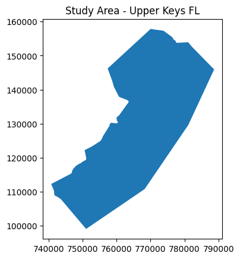

```python
aoi = gpd.read_file(aoi_shapefile)
print(f"AOI CRS: {aoi.crs}")
aoi.plot()
plt.title("Study Area - Upper Keys FL")
plt.show()
```

## Function: Find SCL File

SCL layer uses 20m resolution band inside `.SAFE` folder and is only available for L2A (2017-2024 for this analysis).

```python
def find_scl(scene_id, year, sentinel_dir):
    """Locate the SCL jp2file for a given scene_id inside sentinel2_data."""
    year_path = os.path.join(sentinel_dir, str(year))

    # match SAFE folder containing the scene datetime
    datetime_str = scene_id.split("_")[1]
    safe_matches = glob.glob(os.path.join(year_path, f"*{datetime_str}*.SAFE"))
    if not safe_matches:
        return None

    safe = safe_matches[0]
    scl_files = glob.glob(os.path.join(safe, "**/*SCL_20m.jp2"), recursive=True)

    return scl_files[0] if scl_files else None
```

## Cloud Mask & Clip

The main loop for each scene:

- opens `.nc` DataSet from `01_access_data`
- reprojects AOI to match CRS of scenes
  - **L2A only:** find SCL in `SAFE` and match 20m band resolution to 10m bands with `reproject_match`, and apply cloud mask.
  - **L1C:** skipping cloud masking
- Clip all bands to AOI
- Save as `processed/clipped/{scene_id}_clipped.nc`, delete from memory.

Note: L1C is only clipped, this most likely will not affect results as cloud coverage was less than 30% when searching.

```python
clipped_records = []
saved_count = 0
skipped_count = 0
failed_count = 0

for _, row in manifest.iterrows():
    scene_id = row["scene_id"]
    year     = row["year"]
    level    = row["level"]
    nc_path  = row["nc_path"]
    out_path = os.path.join(clipped_dir, f"{scene_id}_clipped.nc")

    if os.path.exists(out_path):
        skipped_count += 1
        clipped_records.append({"scene_id": scene_id,
                                "level": level,
                                "year": year,
                                "clipped_path": out_path
        })
        continue
    if not os.path.exists(nc_path):
        print(f"    SKIP (nc not found): {scene_id}")
        failed_count += 1
        continue

    try:
        # open scene DataSet
        ds = xr.open_dataset(nc_path)
        ds = ds.rio.write_crs(ds.rio.crs or "EPSG:32617")

        # reproject AOI to match scene CRS
        aoi_proj = aoi.to_crs(ds.rio.crs)

        # cloud masking for L2A only
        if level == "L2A":
            scl_path = find_scl(scene_id, year, sentinel_dir)
            if scl_path:
                # Load SCL and rematch 20m resolution to 10m bands
                scl = rxr.open_rasterio(scl_path, masked=True).squeeze("band", drop=True)
                scl_10m = scl.rio.reproject_match(ds["blue"]).squeeze("band", drop=True)

                # build cloudmask: True where cloudy
                cloud_mask = np.isin(scl_10m.values, cloud_classes)

                # apply to all bands
                for var in ds.data_vars:
                    ds[var] = ds[var].where(~cloud_mask)

                del scl, scl_10m, cloud_mask
            else:
                print(f"    WARNING (no SCL found, skipping cloud mask): {scene_id}")
        # Clip to AOI
        ds = ds.rio.clip(aoi_proj.geometry, aoi_proj.crs, drop=True, invert=False)

        # immediately save
        encoding = {v: {"zlib": True, "complevel": 4} for v in ds.data_vars}
        ds.to_netcdf(out_path, encoding=encoding)

        clipped_records.append({
                                "scene_id": scene_id,
                                "level": level,
                                "year": year,
                                "clipped_path": out_path
                                })
        saved_count += 1

    except Exception as e:
        print(f"    ERROR ({scene_id}): {e}")
        failed_count += 1

    finally:
        try:
            ds.close()
        except:
            pass
        gc.collect()

print(f"\nDone. saved: {saved_count}    skipped: {skipped_count}    failed: {failed_count}")
```

[output not shown]

[output cut: 80 more lines]

[output not shown]

```python
print(f"Scenes with SCL warnings: check clipped_manifest for flag")
# quick check - how many clipped files exist
import glob
clipped = glob.glob("processed/clipped/*.nc")
print(f"Clipped files on disk: {len(clipped)}")
```

```
Scenes with SCL warnings: check clipped_manifest for flag
Clipped files on disk: 145
```

## Save Clipped Manifest

```python
clipped_df = (
    pd.DataFrame(clipped_records)
    .sort_values(["year", "scene_id"])
    .reset_index(drop=True)
)

clipped_df.to_csv("processed/clipped_manifest.csv", index=False)
print(f"Clipped manifest saved. Total: {len(clipped_df)}")
clipped_df.head()
```

```
Clipped manifest saved. Total: 145
```

|  | scene_id | level | year | clipped_path |
| --- | --- | --- | --- | --- |
| 0 | T17RNH_20151113T160052 | L1C | 2015 | processed/clipped\T17RNH_20151113T160052_clipp... |
| 1 | T17RNJ_20151113T160052 | L1C | 2015 | processed/clipped\T17RNJ_20151113T160052_clipp... |
| 2 | T17RNH_20160302T155402 | L1C | 2016 | processed/clipped\T17RNH_20160302T155402_clipp... |
| 3 | T17RNH_20160630T160512 | L1C | 2016 | processed/clipped\T17RNH_20160630T160512_clipp... |
| 4 | T17RNH_20160720T160512 | L1C | 2016 | processed/clipped\T17RNH_20160720T160512_clipp... |

## Verification Plot

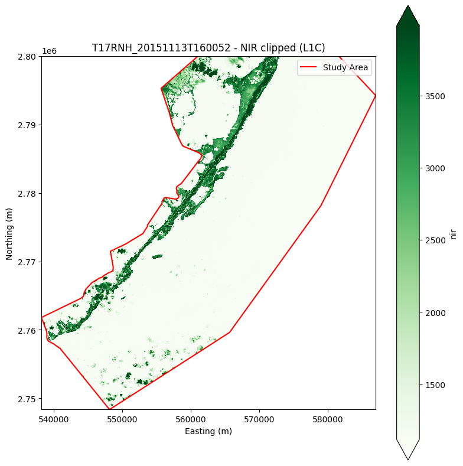

```python
# pick the first clipped scene
sample = clipped_df.iloc[0]
ds_plot = xr.open_dataset(sample["clipped_path"])

aoi_plot = aoi.to_crs(ds_plot.rio.crs)

fig, ax = plt.subplots(figsize=(8,8))

# plot NIR band
ds_plot["nir"].plot(
    ax=ax,
    cmap="Greens",
    robust=True,
    add_colorbar=True,
)

# overlay study area boundary using `boundary.plot()`
aoi_plot.boundary.plot(ax=ax, color="red", linewidth=1.5, label="Study Area")

ax.set_title(f"{sample['scene_id']} - NIR clipped ({sample['level']})")
ax.set_xlabel("Easting (m)")
ax.set_ylabel("Northing (m)")
ax.legend()
plt.tight_layout()
plt.show()

ds_plot.close()
```

## Summary

**Next:** `03_calculate_indices` to load clipped manifest and water quality data from `02b_preprocess_data`, compute NDVI, EVI, NDWI and other vegetation indices

## Resources and references-

- Elshall, A. (2026). *xarray* [Environmental Data Science course notebook] FGCU.
- Code assistance provided by Kiro AI (AWS, 2025). https://kiro.dev
- Wu, Qiusheng (2024). *Rioxarray. In GIS Programming*. https://geog-312.gishub.org/book/geospatial/rioxarray.html
- Wasser, L., et. al. (2022, Jan 21). *Overlay Raster and Vector Spatial Data in A Matplotlib Plot Using Extents in Python*. Earth Data Science. https://earthdatascience.org/courses/scientists-guide-to-plotting-data-in-python/plot-spatial-data/customize-raster-plots/plotting-extents/